# 02_ Seleccion_Variables

### 2. Feature Engineering y Selección de Variables

En este segundo notebook, llevaremos a cabo Feature Engineering que es el proceso de seleccionar, transformar o crear variables en un conjunto de datos con el objetivo de mejorar el rendimiento y la eficacia de los modelos.

Y también realizaremos la Selección de Variables que implica identificar y retener únicamente las variables más relevantes y significativas para el problema en cuestión, descartando aquellas que pueden introducir ruido o tener un impacto limitado en la capacidad predictiva del modelo. La selección de variables busca simplificar y optimizar el modelo, mejorar la interpretación de los resultados y reducir el riesgo de overfitting.

#### Importación librerías y funciones

```python
import pandas as pd
import seaborn as sns
import matplotlib.pyplot as plt
import numpy as np
from sklearn.preprocessing import OneHotEncoder
from sklearn.preprocessing import StandardScaler
from sklearn.linear_model import LassoCV, LogisticRegression
from sklearn.feature_selection import SelectFromModel, RFE

pd.set_option('display.max_columns', 500)
pd.set_option('display.max_rows', 5000)
```

```python
from funciones import get_corr_matrix
```

#### Lectura datos

```python
pd_fraud = pd.read_pickle('../data/eda.pkl')
```

```python
pd_fraud.head()
```

|  | fraud_bool | income | name_email_similarity | prev_address_months_count | current_address_months_count | customer_age | days_since_request | intended_balcon_amount | payment_type | zip_count_4w | velocity_6h | velocity_24h | velocity_4w | bank_branch_count_8w | date_of_birth_distinct_emails_4w | employment_status | credit_risk_score | email_is_free | housing_status | phone_home_valid | phone_mobile_valid | bank_months_count | has_other_cards | proposed_credit_limit | foreign_request | source | session_length_in_minutes | device_os | keep_alive_session | … |
| --- | --- | --- | --- | --- | --- | --- | --- | --- | --- | --- | --- | --- | --- | --- | --- | --- | --- | --- | --- | --- | --- | --- | --- | --- | --- | --- | --- | --- | --- | --- |
| 0 | 1 | 0.9 | 0.166828 | NaN | 88.0 | 50 | 0.020925 | NaN | AA | 769 | 10650.765523 | 3134.319630 | 3863.647740 | 1 | 6 | CA | 185 | 0 | BA | 1 | 0 | 24.0 | 0 | 500.0 | 0 | INTERNET | 3.888115 | windows | 0 | … |
| 1 | 1 | 0.9 | 0.296286 | NaN | 144.0 | 50 | 0.005418 | NaN | AB | 366 | 534.047319 | 2670.918292 | 3124.298166 | 718 | 3 | CA | 259 | 1 | BA | 0 | 0 | 15.0 | 0 | 1500.0 | 0 | INTERNET | 31.798819 | windows | 0 | … |
| 2 | 1 | 0.9 | 0.044985 | NaN | 132.0 | 40 | 3.108549 | NaN | AC | 870 | 4048.534263 | 2893.621498 | 3159.590679 | 1 | 14 | CB | 177 | 1 | BA | 0 | 1 | NaN | 0 | 200.0 | 0 | INTERNET | 4.728705 | other | 0 | … |
| 3 | 1 | 0.9 | 0.159511 | NaN | 22.0 | 50 | 0.019079 | NaN | AB | 810 | 3457.064063 | 4054.908412 | 3022.261812 | 1921 | 6 | CA | 110 | 1 | BA | 0 | 1 | 31.0 | 1 | 200.0 | 0 | INTERNET | 2.047904 | linux | 0 | … |
| 4 | 1 | 0.9 | 0.596414 | NaN | 218.0 | 50 | 0.004441 | NaN | AB | 890 | 5020.341679 | 2728.237159 | 3087.670952 | 1990 | 2 | CA | 295 | 1 | BA | 1 | 0 | 31.0 | 0 | 1500.0 | 0 | INTERNET | 3.775225 | macintosh | 1 | … |

### Feature Engineering

#### Sustitución de valores nulos (NaN)

```python
# Initialize an empty list to store continuous variables
list_continuous_variable = []

# Iterate through each column in the 'pd_fraud' DataFrame
for column in pd_fraud.columns:
    # Check if the data type of the column is not 'category'
    if pd_fraud[column].dtype != 'category':
        # If not a categorical variable, add the column to the list of continuous variables
        list_continuous_variable.append(column)
```

```python
# Fill missing values in continuous variables with their respective column means
pd_fraud[list_continuous_variable] = pd_fraud[list_continuous_variable].apply(lambda x: x.fillna(x.mean()))
```

#### Codificación de las variables categóricas

Llevamos a cabo la codificación de las variables que contienene datos de tipo string para convertirlas en valores numéricos.

En primer lugar, dado el análisis exploratorio conocemos que existe una variable categórica, source, que únicamente tiene dos valores únicos, por tanto simplemente sustituimos la columna actual por una nueva columna que asigna a cada valor único un 0 o un 1 según corresponda.

```python
# Define encoding mapping for 'source' column
source_encoding = {'TELEAPP': 0, 'INTERNET': 1}

# Replace values in the 'source' column using the defined encoding
pd_fraud['source'] = pd_fraud['source'].replace(source_encoding)
```

Posteriomente llevamos a cabo la codificación del resto de variables, estas variables presentan un mayor número de valores únicos pero no nos encontramos ante un gran número de ellos, es por eso por lo que decidimos aplicar la técnica de one-hot encoding.

```python
# Define a list of variables for one-hot encoding
variables_for_onehot = ['payment_type', 'employment_status', 'housing_status', 'device_os']

# Initialize a OneHotEncoder
encoder = OneHotEncoder()

# Encode the specified variables and create a new DataFrame with one-hot encoded features
pd_fraud_encoded = pd.DataFrame(encoder.fit_transform(pd_fraud[variables_for_onehot]).toarray(), columns=encoder.get_feature_names_out(variables_for_onehot))

# Convert the new one-hot encoded DataFrame to the 'category' data type
pd_fraud_encoded = pd_fraud_encoded.astype('category')

# Concatenate the original DataFrame with the one-hot encoded DataFrame
pd_fraud = pd.concat([pd_fraud, pd_fraud_encoded], axis=1)

# Drop the original columns that were one-hot encoded
pd_fraud = pd_fraud.drop(columns=variables_for_onehot)
```

#### Correlaciones variables categóricas

```python
# Identify categorical variables by selecting columns with data types 'object' or 'category'
categorical_var = pd_fraud.select_dtypes(include=['object', 'category']).columns
```

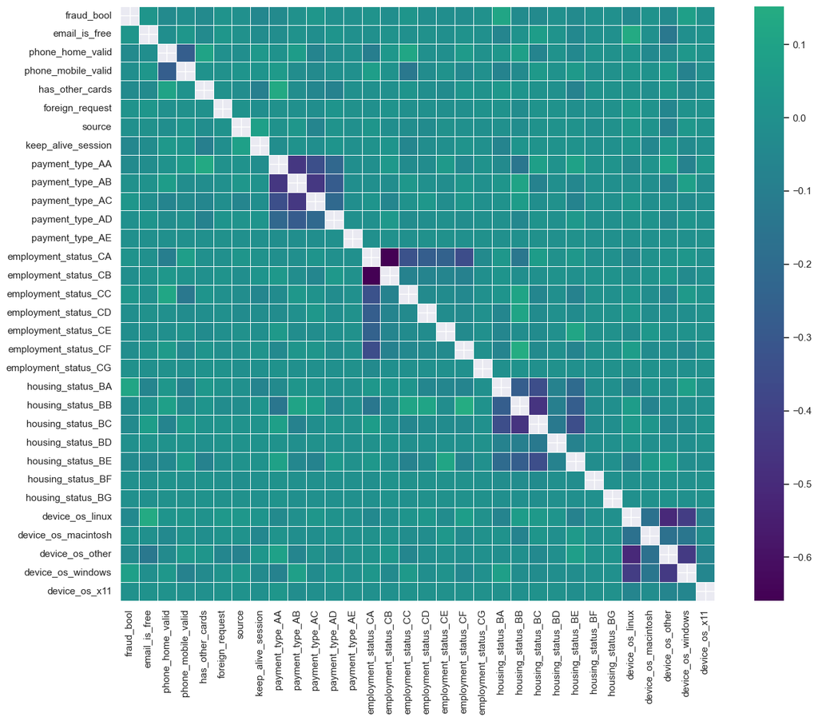

```
0
```

```python
# Calculate and visualize the Spearman correlation matrix for categorical variables in the DataFrame pd_fraud
get_corr_matrix(dataset=pd_fraud[categorical_var], method='spearman', size_figure=[16, 12])
```

Una vez codificadas las variables, aprovechamos para extraer la correlación de las variables categóricas, de esta manera observamos que únicamente existe una correlacion relativamente fuerte entre employment_status_CB y employment_status_CA. Para el resto de variables la correlación es moderada o prácticamente inexistente.

```python
# Calculate the Spearman correlation matrix for categorical variables in the DataFrame pd_fraud
corr = pd_fraud[categorical_var].corr('spearman')

# Create a new DataFrame with the absolute values of the lower triangular part of the correlation matrix
new_corr = corr.abs()

# Set values above the main diagonal to zero
new_corr.loc[:, :] = np.tril(new_corr, k=-1)

# Stack the lower triangular part of the correlation matrix into a DataFrame
new_corr = new_corr.stack().to_frame('correlation').reset_index()

# Sort the DataFrame by the 'correlation' column in descending order
new_corr = new_corr.sort_values(by='correlation', ascending=False)

# Filter the DataFrame to include only correlations greater than 0.6
high_corr_df = new_corr[new_corr['correlation'] > 0.6]
```

#### Escalado de variables

El escalado de variables es una etapa crucial diseñada para asegurar que las características del conjunto de datos estén en una escala uniforme. Esta uniformidad es esencial porque muchos algoritmos son sensibles a las diferencias en la magnitud de las variables. Sin el escalado adecuado, las características con unidades más grandes o rangos más amplios pueden dominar la contribución al modelo, sesgando los resultados y afectando la capacidad del modelo para aprender patrones de manera equitativa.

```python
# Initialize a StandardScaler for feature scaling
scaler = StandardScaler()

# Separate the target variable and features from the DataFrame
target_variable = pd_fraud['fraud_bool']
features_to_scale = pd_fraud.drop(['fraud_bool'], axis=1)

# Scale the features using the StandardScaler
scaled_features = scaler.fit_transform(features_to_scale)

# Create a new DataFrame with the scaled features
scaled_df = pd.DataFrame(scaled_features, columns=features_to_scale.columns)

# Insert the target variable back into the DataFrame as the first column
scaled_df.insert(0, 'fraud_bool', target_variable)

# Update the original DataFrame 'pd_fraud' with the scaled DataFrame
pd_fraud = scaled_df
```

### Selección de Variables

#### Importancia de variables (Lasso)

Posteriormente, decidimos ejecutar el algoritmo Lasso, pero no lo utilizaremos de manera predictiva, sino que simplemente lo emplearemos para extraer la importancia de las variables, de esta forma nos servirá como elemento de apoyo adicional a la hora de decidir que variables excluir y cuales mantener para introducir en el modelo.

```python
# Separate features (X) and the target variable (y) from the DataFrame
X = pd_fraud.drop(columns='fraud_bool')
y = pd_fraud['fraud_bool']
```

```python
# Initialize and fit a LASSO feature selection model
sel_lasso = SelectFromModel(LogisticRegression(C=1, penalty='l1', solver='liblinear'))
sel_lasso.fit(X, y)
```

```
SelectFromModel(estimator=LogisticRegression(C=1, penalty='l1',
                                             solver='liblinear'))
```

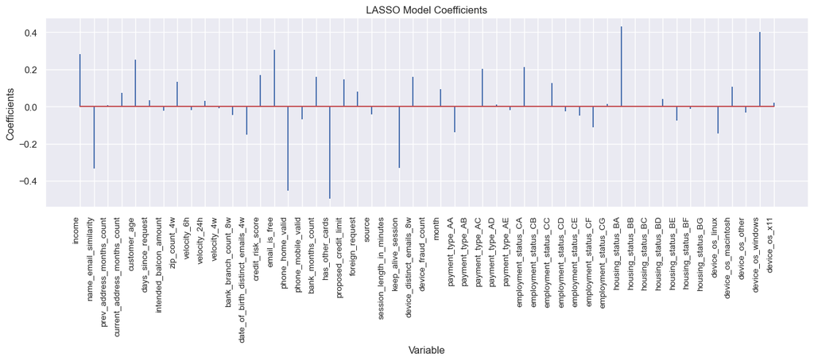

```python
# Create a DataFrame with predictor names and their corresponding coefficients from the LASSO model
df_coeficientes_lasso = pd.DataFrame(
    {'predictor': X.columns,
     'coef': sel_lasso.estimator_.coef_.flatten()}
)

# Create a stem plot to visualize LASSO coefficients
fig, ax = plt.subplots(figsize=(16, 4))
ax.stem(df_coeficientes_lasso.predictor, df_coeficientes_lasso.coef, markerfmt=' ')

# Customize plot labels and title
plt.xticks(rotation=90, ha='right', size=10)
ax.set_xlabel('Variable')
ax.set_ylabel('Coefficients')
ax.set_title('LASSO Model Coefficients')
```

Extraemos los coeficientes y ordenamos por importancia

```python
# Sort the DataFrame of LASSO coefficients based on the absolute values of coefficients in descending order
df_sorted = df_coeficientes_lasso.reindex(df_coeficientes_lasso['coef'].abs().sort_values(ascending=False).index)

# Display the sorted DataFrame
df_sorted
```

|  | predictor | coef |
| --- | --- | --- |
| 18 | has_other_cards | -0.497159 |
| 15 | phone_home_valid | -0.454276 |
| 39 | housing_status_BA | 0.429934 |
| 49 | device_os_windows | 0.401703 |
| 1 | name_email_similarity | -0.334692 |
| 23 | keep_alive_session | -0.330829 |
| 14 | email_is_free | 0.305844 |
| 0 | income | 0.282308 |
| 4 | customer_age | 0.252400 |
| 32 | employment_status_CA | 0.213750 |
| 29 | payment_type_AC | 0.203348 |
| 13 | credit_risk_score | 0.168379 |
| 17 | bank_months_count | 0.161175 |
| 24 | device_distinct_emails_8w | 0.158944 |
| 12 | date_of_birth_distinct_emails_4w | -0.150336 |
| 19 | proposed_credit_limit | 0.147848 |
| 46 | device_os_linux | -0.146170 |
| 27 | payment_type_AA | -0.138288 |
| 7 | zip_count_4w | 0.131587 |
| 34 | employment_status_CC | 0.125438 |
| 37 | employment_status_CF | -0.111719 |
| 47 | device_os_macintosh | 0.105641 |
| 26 | month | 0.092346 |
| 20 | foreign_request | 0.079479 |
| 43 | housing_status_BE | -0.075571 |
| 3 | current_address_months_count | 0.074437 |
| 16 | phone_mobile_valid | -0.069501 |
| 36 | employment_status_CE | -0.047474 |
| 11 | bank_branch_count_8w | -0.047144 |
| 21 | source | -0.042593 |
| 42 | housing_status_BD | 0.041437 |
| 5 | days_since_request | 0.034554 |
| 48 | device_os_other | -0.031221 |
| 9 | velocity_24h | 0.031005 |
| 35 | employment_status_CD | -0.025853 |
| 6 | intended_balcon_amount | -0.023227 |
| 50 | device_os_x11 | 0.020635 |
| 8 | velocity_6h | -0.019735 |
| 31 | payment_type_AE | -0.018313 |
| 38 | employment_status_CG | 0.012335 |
| 44 | housing_status_BF | -0.012025 |
| 30 | payment_type_AD | 0.011974 |
| 2 | prev_address_months_count | 0.008802 |
| 10 | velocity_4w | -0.007992 |
| 40 | housing_status_BB | -0.003172 |
| 22 | session_length_in_minutes | 0.002982 |
| 45 | housing_status_BG | -0.002639 |
| 33 | employment_status_CB | 0.000000 |
| 41 | housing_status_BC | 0.000000 |
| 28 | payment_type_AB | 0.000000 |
| 25 | device_fraud_count | 0.000000 |

#### Eliminación de variables

Optamos por eliminar las siguientes variables, antes de entrenar el modelo.

- device_fraud_count: Es una constante y mantenerla no aporta nada al modelo.
- session_lenght_in_minutes y prev_address_months_count: Son dos variables con una muy escasa importancia como hemos visto a través del algoritmo Lasso, además la variable prev_address_months_count presenta un muy elevado número de nulos.
- velocity_4w: Es una variable que posee poco importancia y también tiene una elevada correlación negativa, superior al 80% con la variable month.

```python
# Drop specific columns from the DataFrame pd_fraud
pd_fraud = pd_fraud.drop(['device_fraud_count', 'session_length_in_minutes', 'prev_address_months_count', 'velocity_4w'], axis=1)
```

```python
# Save the DataFrame pd_fraud to a CSV file named 'seleccion.csv' in the 'data' directory, without including the index
pd_fraud.to_csv('../data/seleccion.csv', index=False)
```